# Risk Factor Analysis

## Outcome Variable

**Outcome Variable:** haz

## Predictor Variables

**Intervention Variable:** mwtkg

**Adjustment Set:**

- arm
- W_mage
- W_fage
- meducyrs
- feducyrs
- single
- brthmon
- W_gagebrth
- W_birthwt
- W_birthlen
- vagbrth
- delta_W_mage
- delta_W_fage
- delta_meducyrs
- delta_feducyrs
- delta_single
- delta_brthmon
- delta_W_gagebrth
- delta_W_birthwt
- delta_W_birthlen
- delta_vagbrth

## Stratifying Variables

The analysis was stratified on these variable(s):

- agecat
- studyid
- country

## Data Summary

| agecat | studyid | country | mwtkg | n_cell | n |
| --- | --- | --- | --- | --- | --- |
| 6 months | ki0047075b-MAL-ED | BANGLADESH | >=58 kg | 46 | 241 |
| 6 months | ki0047075b-MAL-ED | BANGLADESH | <52 kg | 154 | 241 |
| 6 months | ki0047075b-MAL-ED | BANGLADESH | [52-58) kg | 41 | 241 |
| 6 months | ki0047075b-MAL-ED | BRAZIL | >=58 kg | 137 | 208 |
| 6 months | ki0047075b-MAL-ED | BRAZIL | <52 kg | 37 | 208 |
| 6 months | ki0047075b-MAL-ED | BRAZIL | [52-58) kg | 34 | 208 |
| 6 months | ki0047075b-MAL-ED | INDIA | >=58 kg | 40 | 235 |
| 6 months | ki0047075b-MAL-ED | INDIA | <52 kg | 146 | 235 |
| 6 months | ki0047075b-MAL-ED | INDIA | [52-58) kg | 49 | 235 |
| 6 months | ki0047075b-MAL-ED | NEPAL | >=58 kg | 79 | 236 |
| 6 months | ki0047075b-MAL-ED | NEPAL | <52 kg | 75 | 236 |
| 6 months | ki0047075b-MAL-ED | NEPAL | [52-58) kg | 82 | 236 |
| 6 months | ki0047075b-MAL-ED | PERU | >=58 kg | 100 | 272 |
| 6 months | ki0047075b-MAL-ED | PERU | <52 kg | 107 | 272 |
| 6 months | ki0047075b-MAL-ED | PERU | [52-58) kg | 65 | 272 |
| 6 months | ki0047075b-MAL-ED | SOUTH AFRICA | >=58 kg | 179 | 249 |
| 6 months | ki0047075b-MAL-ED | SOUTH AFRICA | <52 kg | 29 | 249 |
| 6 months | ki0047075b-MAL-ED | SOUTH AFRICA | [52-58) kg | 41 | 249 |
| 6 months | ki0047075b-MAL-ED | TANZANIA, UNITED REPUBLIC OF | >=58 kg | 94 | 247 |
| 6 months | ki0047075b-MAL-ED | TANZANIA, UNITED REPUBLIC OF | <52 kg | 95 | 247 |
| 6 months | ki0047075b-MAL-ED | TANZANIA, UNITED REPUBLIC OF | [52-58) kg | 58 | 247 |
| 6 months | ki1000304b-SAS-CompFeed | INDIA | >=58 kg | 99 | 1330 |
| 6 months | ki1000304b-SAS-CompFeed | INDIA | <52 kg | 1019 | 1330 |
| 6 months | ki1000304b-SAS-CompFeed | INDIA | [52-58) kg | 212 | 1330 |
| 6 months | ki1017093-NIH-Birth | BANGLADESH | >=58 kg | 71 | 537 |
| 6 months | ki1017093-NIH-Birth | BANGLADESH | <52 kg | 385 | 537 |
| 6 months | ki1017093-NIH-Birth | BANGLADESH | [52-58) kg | 81 | 537 |
| 6 months | ki1017093b-PROVIDE | BANGLADESH | >=58 kg | 107 | 582 |
| 6 months | ki1017093b-PROVIDE | BANGLADESH | <52 kg | 369 | 582 |
| 6 months | ki1017093b-PROVIDE | BANGLADESH | [52-58) kg | 106 | 582 |

[output cut: 57 more lines]

The following strata were considered:

- agecat: 24 months, studyid: ki0047075b-MAL-ED, country: BANGLADESH
- agecat: 24 months, studyid: ki0047075b-MAL-ED, country: BRAZIL
- agecat: 24 months, studyid: ki0047075b-MAL-ED, country: INDIA
- agecat: 24 months, studyid: ki0047075b-MAL-ED, country: NEPAL
- agecat: 24 months, studyid: ki0047075b-MAL-ED, country: PERU
- agecat: 24 months, studyid: ki0047075b-MAL-ED, country: SOUTH AFRICA
- agecat: 24 months, studyid: ki0047075b-MAL-ED, country: TANZANIA, UNITED REPUBLIC OF
- agecat: 24 months, studyid: ki1017093-NIH-Birth, country: BANGLADESH
- agecat: 24 months, studyid: ki1017093b-PROVIDE, country: BANGLADESH
- agecat: 24 months, studyid: ki1017093c-NIH-Crypto, country: BANGLADESH
- agecat: 24 months, studyid: ki1066203-TanzaniaChild2, country: TANZANIA, UNITED REPUBLIC OF
- agecat: 24 months, studyid: ki1119695-PROBIT, country: BELARUS
- agecat: 24 months, studyid: ki1126311-ZVITAMBO, country: ZIMBABWE
- agecat: 24 months, studyid: ki1148112-LCNI-5, country: MALAWI
- agecat: 6 months, studyid: ki0047075b-MAL-ED, country: BANGLADESH
- agecat: 6 months, studyid: ki0047075b-MAL-ED, country: BRAZIL
- agecat: 6 months, studyid: ki0047075b-MAL-ED, country: INDIA
- agecat: 6 months, studyid: ki0047075b-MAL-ED, country: NEPAL
- agecat: 6 months, studyid: ki0047075b-MAL-ED, country: PERU
- agecat: 6 months, studyid: ki0047075b-MAL-ED, country: SOUTH AFRICA
- agecat: 6 months, studyid: ki0047075b-MAL-ED, country: TANZANIA, UNITED REPUBLIC OF
- agecat: 6 months, studyid: ki1000304b-SAS-CompFeed, country: INDIA
- agecat: 6 months, studyid: ki1017093-NIH-Birth, country: BANGLADESH
- agecat: 6 months, studyid: ki1017093b-PROVIDE, country: BANGLADESH
- agecat: 6 months, studyid: ki1017093c-NIH-Crypto, country: BANGLADESH
- agecat: 6 months, studyid: ki1066203-TanzaniaChild2, country: TANZANIA, UNITED REPUBLIC OF
- agecat: 6 months, studyid: ki1119695-PROBIT, country: BELARUS
- agecat: 6 months, studyid: ki1126311-ZVITAMBO, country: ZIMBABWE
- agecat: 6 months, studyid: ki1148112-LCNI-5, country: MALAWI

### Dropped Strata

Some strata were dropped due to rare outcomes:

- agecat: 24 months, studyid: ki1066203-TanzaniaChild2, country: TANZANIA, UNITED REPUBLIC OF

## Methods Detail

We’re interested in the causal parameters $E[Y_a]$ for all values of $a \in \mathcal{A}$. These parameters represent the mean outcome if, possibly contrary to fact, we intervened to set all units to have $A=a$. Under the randomization and positivity assumptions, these are identified by the statistical parameters $\psi_a=E_W[E_{Y|A,W}(Y|A=a,W)]$. In addition, we’re interested in the mean of $Y$, $E[Y]$ under no intervention (the observed mean). We will estimate these parameters by using SuperLearner to fit the relevant likelihood factors – $E_{Y|A,W}(Y|A=a,W)$ and $p(A=a|W)$, and then updating our likelihood fit using a joint TMLE.

For unadjusted analyses ($W=\{\}$), initial likelihoods were estimated using Lrnr_glm to estimate the simple $E(Y|A)$ and Lrnr_mean to estimate $p(A)$. For adjusted analyses, a small library containing Lrnr_glmnet, Lrnr_xgboost, and Lrnr_mean was used.

Having estimated these parameters, we will then use the delta method to estimate relative risks and attributable risks relative to a prespecified baseline level of $A$.

# Results Detail

## Results Plots

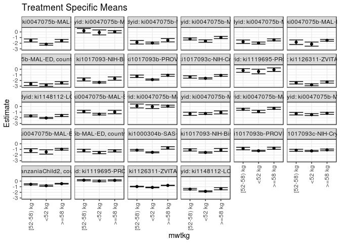

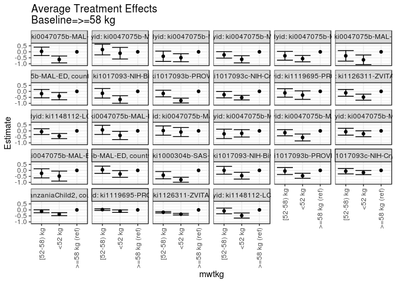

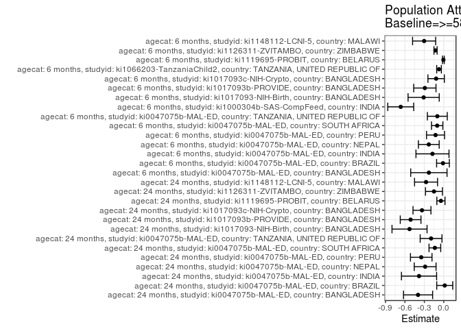

## Results Table

### Parameter: TSM

| agecat | studyid | country | intervention_level | baseline_level | estimate | ci_lower | ci_upper |
| --- | --- | --- | --- | --- | --- | --- | --- |
| 6 months | ki0047075b-MAL-ED | BANGLADESH | >=58 kg | NA | -0.9755619 | -1.2811937 | -0.6699301 |
| 6 months | ki0047075b-MAL-ED | BANGLADESH | <52 kg | NA | -1.3562397 | -1.5104049 | -1.2020744 |
| 6 months | ki0047075b-MAL-ED | BANGLADESH | [52-58) kg | NA | -0.8944998 | -1.1236192 | -0.6653804 |
| 6 months | ki0047075b-MAL-ED | BRAZIL | >=58 kg | NA | 0.0649520 | -0.1119611 | 0.2418651 |
| 6 months | ki0047075b-MAL-ED | BRAZIL | <52 kg | NA | -0.0317320 | -0.3635725 | 0.3001084 |
| 6 months | ki0047075b-MAL-ED | BRAZIL | [52-58) kg | NA | 0.0890597 | -0.2586524 | 0.4367718 |
| 6 months | ki0047075b-MAL-ED | INDIA | >=58 kg | NA | -1.0405510 | -1.3072979 | -0.7738040 |
| 6 months | ki0047075b-MAL-ED | INDIA | <52 kg | NA | -1.2458024 | -1.4023677 | -1.0892371 |
| 6 months | ki0047075b-MAL-ED | INDIA | [52-58) kg | NA | -1.2906792 | -1.5724867 | -1.0088716 |
| 6 months | ki0047075b-MAL-ED | NEPAL | >=58 kg | NA | -0.3297547 | -0.5148834 | -0.1446260 |
| 6 months | ki0047075b-MAL-ED | NEPAL | <52 kg | NA | -0.8815723 | -1.1001852 | -0.6629594 |
| 6 months | ki0047075b-MAL-ED | NEPAL | [52-58) kg | NA | -0.4845071 | -0.6622973 | -0.3067170 |
| 6 months | ki0047075b-MAL-ED | PERU | >=58 kg | NA | -1.2005326 | -1.3731478 | -1.0279173 |
| 6 months | ki0047075b-MAL-ED | PERU | <52 kg | NA | -1.4411227 | -1.6141929 | -1.2680525 |
| 6 months | ki0047075b-MAL-ED | PERU | [52-58) kg | NA | -1.2727323 | -1.5012555 | -1.0442091 |
| 6 months | ki0047075b-MAL-ED | SOUTH AFRICA | >=58 kg | NA | -0.9712422 | -1.1236647 | -0.8188198 |
| 6 months | ki0047075b-MAL-ED | SOUTH AFRICA | <52 kg | NA | -1.4472889 | -1.8339975 | -1.0605803 |
| 6 months | ki0047075b-MAL-ED | SOUTH AFRICA | [52-58) kg | NA | -1.2170581 | -1.5614653 | -0.8726510 |
| 6 months | ki0047075b-MAL-ED | TANZANIA, UNITED REPUBLIC OF | >=58 kg | NA | -1.2606940 | -1.4578645 | -1.0635235 |
| 6 months | ki0047075b-MAL-ED | TANZANIA, UNITED REPUBLIC OF | <52 kg | NA | -1.5595662 | -1.7569008 | -1.3622316 |
| 6 months | ki0047075b-MAL-ED | TANZANIA, UNITED REPUBLIC OF | [52-58) kg | NA | -1.2080414 | -1.4438182 | -0.9722645 |
| 6 months | ki1000304b-SAS-CompFeed | INDIA | >=58 kg | NA | -0.7356543 | -0.9502115 | -0.5210971 |
| 6 months | ki1000304b-SAS-CompFeed | INDIA | <52 kg | NA | -1.5143701 | -1.6033615 | -1.4253787 |
| 6 months | ki1000304b-SAS-CompFeed | INDIA | [52-58) kg | NA | -1.1361960 | -1.2641623 | -1.0082297 |
| 6 months | ki1017093-NIH-Birth | BANGLADESH | >=58 kg | NA | -1.0966392 | -1.3560390 | -0.8372395 |
| 6 months | ki1017093-NIH-Birth | BANGLADESH | <52 kg | NA | -1.5384417 | -1.6434616 | -1.4334219 |
| 6 months | ki1017093-NIH-Birth | BANGLADESH | [52-58) kg | NA | -1.0903278 | -1.2879123 | -0.8927433 |
| 6 months | ki1017093b-PROVIDE | BANGLADESH | >=58 kg | NA | -0.7926995 | -0.9830026 | -0.6023964 |
| 6 months | ki1017093b-PROVIDE | BANGLADESH | <52 kg | NA | -1.2425448 | -1.3318650 | -1.1532246 |
| 6 months | ki1017093b-PROVIDE | BANGLADESH | [52-58) kg | NA | -0.8463651 | -1.0640668 | -0.6286634 |

[output cut: 54 more lines]

### Parameter: E(Y)

| agecat | studyid | country | intervention_level | baseline_level | estimate | ci_lower | ci_upper |
| --- | --- | --- | --- | --- | --- | --- | --- |
| 6 months | ki0047075b-MAL-ED | BANGLADESH | NA | NA | -1.2056777 | -1.3231497 | -1.0882058 |
| 6 months | ki0047075b-MAL-ED | BRAZIL | NA | NA | 0.0532131 | -0.0914567 | 0.1978830 |
| 6 months | ki0047075b-MAL-ED | INDIA | NA | NA | -1.2148369 | -1.3332371 | -1.0964367 |
| 6 months | ki0047075b-MAL-ED | NEPAL | NA | NA | -0.5610593 | -0.6737915 | -0.4483272 |
| 6 months | ki0047075b-MAL-ED | PERU | NA | NA | -1.3272488 | -1.4359649 | -1.2185326 |
| 6 months | ki0047075b-MAL-ED | SOUTH AFRICA | NA | NA | -1.0728012 | -1.2026830 | -0.9429194 |
| 6 months | ki0047075b-MAL-ED | TANZANIA, UNITED REPUBLIC OF | NA | NA | -1.3601215 | -1.4821830 | -1.2380600 |
| 6 months | ki1000304b-SAS-CompFeed | INDIA | NA | NA | -1.4006917 | -1.4821813 | -1.3192022 |
| 6 months | ki1017093-NIH-Birth | BANGLADESH | NA | NA | -1.4073821 | -1.4960598 | -1.3187043 |
| 6 months | ki1017093b-PROVIDE | BANGLADESH | NA | NA | -1.0848568 | -1.1613109 | -1.0084028 |
| 6 months | ki1017093c-NIH-Crypto | BANGLADESH | NA | NA | -1.1986783 | -1.2700937 | -1.1272630 |
| 6 months | ki1066203-TanzaniaChild2 | TANZANIA, UNITED REPUBLIC OF | NA | NA | -0.5424765 | -0.5918460 | -0.4931071 |
| 6 months | ki1119695-PROBIT | BELARUS | NA | NA | 0.1143882 | 0.0212298 | 0.2075466 |
| 6 months | ki1126311-ZVITAMBO | ZIMBABWE | NA | NA | -0.8994195 | -0.9257684 | -0.8730707 |
| 6 months | ki1148112-LCNI-5 | MALAWI | NA | NA | -1.6584707 | -1.7281551 | -1.5887863 |
| 24 months | ki0047075b-MAL-ED | BANGLADESH | NA | NA | -1.9431132 | -2.0691678 | -1.8170586 |
| 24 months | ki0047075b-MAL-ED | BRAZIL | NA | NA | 0.0418452 | -0.1263708 | 0.2100613 |
| 24 months | ki0047075b-MAL-ED | INDIA | NA | NA | -1.8439159 | -1.9704751 | -1.7173568 |
| 24 months | ki0047075b-MAL-ED | NEPAL | NA | NA | -1.2752193 | -1.3954783 | -1.1549603 |
| 24 months | ki0047075b-MAL-ED | PERU | NA | NA | -1.7500995 | -1.8705474 | -1.6296516 |
| 24 months | ki0047075b-MAL-ED | SOUTH AFRICA | NA | NA | -1.6220299 | -1.7590593 | -1.4850005 |
| 24 months | ki0047075b-MAL-ED | TANZANIA, UNITED REPUBLIC OF | NA | NA | -2.6058879 | -2.7403043 | -2.4714714 |
| 24 months | ki1017093-NIH-Birth | BANGLADESH | NA | NA | -2.1807945 | -2.2835902 | -2.0779987 |
| 24 months | ki1017093b-PROVIDE | BANGLADESH | NA | NA | -1.5839236 | -1.6672059 | -1.5006413 |
| 24 months | ki1017093c-NIH-Crypto | BANGLADESH | NA | NA | -1.4295331 | -1.5127726 | -1.3462935 |
| 24 months | ki1119695-PROBIT | BELARUS | NA | NA | -0.1312742 | -0.4286264 | 0.1660780 |
| 24 months | ki1126311-ZVITAMBO | ZIMBABWE | NA | NA | -2.4241972 | -2.5387692 | -2.3096253 |
| 24 months | ki1148112-LCNI-5 | MALAWI | NA | NA | -1.8747405 | -1.9558403 | -1.7936407 |

### Parameter: ATE

| agecat | studyid | country | intervention_level | baseline_level | estimate | ci_lower | ci_upper |
| --- | --- | --- | --- | --- | --- | --- | --- |
| 6 months | ki0047075b-MAL-ED | BANGLADESH | >=58 kg | >=58 kg | 0.0000000 | 0.0000000 | 0.0000000 |
| 6 months | ki0047075b-MAL-ED | BANGLADESH | <52 kg | >=58 kg | -0.3806778 | -0.7237975 | -0.0375580 |
| 6 months | ki0047075b-MAL-ED | BANGLADESH | [52-58) kg | >=58 kg | 0.0810621 | -0.3013814 | 0.4635056 |
| 6 months | ki0047075b-MAL-ED | BRAZIL | >=58 kg | >=58 kg | 0.0000000 | 0.0000000 | 0.0000000 |
| 6 months | ki0047075b-MAL-ED | BRAZIL | <52 kg | >=58 kg | -0.0966840 | -0.4719606 | 0.2785925 |
| 6 months | ki0047075b-MAL-ED | BRAZIL | [52-58) kg | >=58 kg | 0.0241077 | -0.3626876 | 0.4109030 |
| 6 months | ki0047075b-MAL-ED | INDIA | >=58 kg | >=58 kg | 0.0000000 | 0.0000000 | 0.0000000 |
| 6 months | ki0047075b-MAL-ED | INDIA | <52 kg | >=58 kg | -0.2052514 | -0.5149900 | 0.1044871 |
| 6 months | ki0047075b-MAL-ED | INDIA | [52-58) kg | >=58 kg | -0.2501282 | -0.6382010 | 0.1379446 |
| 6 months | ki0047075b-MAL-ED | NEPAL | >=58 kg | >=58 kg | 0.0000000 | 0.0000000 | 0.0000000 |
| 6 months | ki0047075b-MAL-ED | NEPAL | <52 kg | >=58 kg | -0.5518176 | -0.8388147 | -0.2648205 |
| 6 months | ki0047075b-MAL-ED | NEPAL | [52-58) kg | >=58 kg | -0.1547525 | -0.4135390 | 0.1040340 |
| 6 months | ki0047075b-MAL-ED | PERU | >=58 kg | >=58 kg | 0.0000000 | 0.0000000 | 0.0000000 |
| 6 months | ki0047075b-MAL-ED | PERU | <52 kg | >=58 kg | -0.2405902 | -0.4856057 | 0.0044253 |
| 6 months | ki0047075b-MAL-ED | PERU | [52-58) kg | >=58 kg | -0.0721997 | -0.3590852 | 0.2146858 |
| 6 months | ki0047075b-MAL-ED | SOUTH AFRICA | >=58 kg | >=58 kg | 0.0000000 | 0.0000000 | 0.0000000 |
| 6 months | ki0047075b-MAL-ED | SOUTH AFRICA | <52 kg | >=58 kg | -0.4760467 | -0.8918754 | -0.0602179 |
| 6 months | ki0047075b-MAL-ED | SOUTH AFRICA | [52-58) kg | >=58 kg | -0.2458159 | -0.6233120 | 0.1316801 |
| 6 months | ki0047075b-MAL-ED | TANZANIA, UNITED REPUBLIC OF | >=58 kg | >=58 kg | 0.0000000 | 0.0000000 | 0.0000000 |
| 6 months | ki0047075b-MAL-ED | TANZANIA, UNITED REPUBLIC OF | <52 kg | >=58 kg | -0.2988722 | -0.5751367 | -0.0226076 |
| 6 months | ki0047075b-MAL-ED | TANZANIA, UNITED REPUBLIC OF | [52-58) kg | >=58 kg | 0.0526526 | -0.2526684 | 0.3579737 |
| 6 months | ki1000304b-SAS-CompFeed | INDIA | >=58 kg | >=58 kg | 0.0000000 | 0.0000000 | 0.0000000 |
| 6 months | ki1000304b-SAS-CompFeed | INDIA | <52 kg | >=58 kg | -0.7787158 | -0.9867975 | -0.5706342 |
| 6 months | ki1000304b-SAS-CompFeed | INDIA | [52-58) kg | >=58 kg | -0.4005417 | -0.7031260 | -0.0979574 |
| 6 months | ki1017093-NIH-Birth | BANGLADESH | >=58 kg | >=58 kg | 0.0000000 | 0.0000000 | 0.0000000 |
| 6 months | ki1017093-NIH-Birth | BANGLADESH | <52 kg | >=58 kg | -0.4418025 | -0.7214238 | -0.1621812 |
| 6 months | ki1017093-NIH-Birth | BANGLADESH | [52-58) kg | >=58 kg | 0.0063114 | -0.3197297 | 0.3323525 |
| 6 months | ki1017093b-PROVIDE | BANGLADESH | >=58 kg | >=58 kg | 0.0000000 | 0.0000000 | 0.0000000 |
| 6 months | ki1017093b-PROVIDE | BANGLADESH | <52 kg | >=58 kg | -0.4498453 | -0.6602091 | -0.2394815 |
| 6 months | ki1017093b-PROVIDE | BANGLADESH | [52-58) kg | >=58 kg | -0.0536656 | -0.3429186 | 0.2355874 |

[output cut: 54 more lines]

### Parameter: PAR

| agecat | studyid | country | intervention_level | baseline_level | estimate | ci_lower | ci_upper |
| --- | --- | --- | --- | --- | --- | --- | --- |
| 6 months | ki0047075b-MAL-ED | BANGLADESH | >=58 kg | NA | -0.2301158 | -0.5107437 | 0.0505120 |
| 6 months | ki0047075b-MAL-ED | BRAZIL | >=58 kg | NA | -0.0117389 | -0.1103364 | 0.0868587 |
| 6 months | ki0047075b-MAL-ED | INDIA | >=58 kg | NA | -0.1742859 | -0.4295428 | 0.0809710 |
| 6 months | ki0047075b-MAL-ED | NEPAL | >=58 kg | NA | -0.2313046 | -0.3918373 | -0.0707720 |
| 6 months | ki0047075b-MAL-ED | PERU | >=58 kg | NA | -0.1267162 | -0.2661215 | 0.0126891 |
| 6 months | ki0047075b-MAL-ED | SOUTH AFRICA | >=58 kg | NA | -0.1015590 | -0.1892800 | -0.0138380 |
| 6 months | ki0047075b-MAL-ED | TANZANIA, UNITED REPUBLIC OF | >=58 kg | NA | -0.0994275 | -0.2532418 | 0.0543869 |
| 6 months | ki1000304b-SAS-CompFeed | INDIA | >=58 kg | NA | -0.6650374 | -0.8651862 | -0.4648887 |
| 6 months | ki1017093-NIH-Birth | BANGLADESH | >=58 kg | NA | -0.3107428 | -0.5515215 | -0.0699641 |
| 6 months | ki1017093b-PROVIDE | BANGLADESH | >=58 kg | NA | -0.2921573 | -0.4645022 | -0.1198125 |
| 6 months | ki1017093c-NIH-Crypto | BANGLADESH | >=58 kg | NA | -0.1176175 | -0.2445200 | 0.0092850 |
| 6 months | ki1066203-TanzaniaChild2 | TANZANIA, UNITED REPUBLIC OF | >=58 kg | NA | -0.0730567 | -0.1092046 | -0.0369088 |
| 6 months | ki1119695-PROBIT | BELARUS | >=58 kg | NA | -0.0055731 | -0.0191821 | 0.0080358 |
| 6 months | ki1126311-ZVITAMBO | ZIMBABWE | >=58 kg | NA | -0.1270605 | -0.1513358 | -0.1027853 |
| 6 months | ki1148112-LCNI-5 | MALAWI | >=58 kg | NA | -0.3032016 | -0.4817912 | -0.1246121 |
| 24 months | ki0047075b-MAL-ED | BANGLADESH | >=58 kg | NA | -0.3972034 | -0.6223018 | -0.1721050 |
| 24 months | ki0047075b-MAL-ED | BRAZIL | >=58 kg | NA | 0.0153949 | -0.1081732 | 0.1389631 |
| 24 months | ki0047075b-MAL-ED | INDIA | >=58 kg | NA | -0.3821164 | -0.6538779 | -0.1103548 |
| 24 months | ki0047075b-MAL-ED | NEPAL | >=58 kg | NA | -0.2876689 | -0.4562507 | -0.1190871 |
| 24 months | ki0047075b-MAL-ED | PERU | >=58 kg | NA | -0.3479302 | -0.5143686 | -0.1814918 |
| 24 months | ki0047075b-MAL-ED | SOUTH AFRICA | >=58 kg | NA | -0.1372379 | -0.2276958 | -0.0467800 |
| 24 months | ki0047075b-MAL-ED | TANZANIA, UNITED REPUBLIC OF | >=58 kg | NA | -0.1957740 | -0.3644307 | -0.0271173 |
| 24 months | ki1017093-NIH-Birth | BANGLADESH | >=58 kg | NA | -0.5290292 | -0.7999234 | -0.2581351 |
| 24 months | ki1017093b-PROVIDE | BANGLADESH | >=58 kg | NA | -0.5120901 | -0.6721314 | -0.3520487 |
| 24 months | ki1017093c-NIH-Crypto | BANGLADESH | >=58 kg | NA | -0.3365289 | -0.4751233 | -0.1979344 |
| 24 months | ki1119695-PROBIT | BELARUS | >=58 kg | NA | -0.0437649 | -0.1067667 | 0.0192368 |
| 24 months | ki1126311-ZVITAMBO | ZIMBABWE | >=58 kg | NA | -0.1510096 | -0.2821397 | -0.0198794 |
| 24 months | ki1148112-LCNI-5 | MALAWI | >=58 kg | NA | -0.2735724 | -0.4513150 | -0.0958298 |